# exercicio1

```python
#importando as bibliotecas

import pandas as pd #biblioteca que lida com os dados e cria o dataframe
import matplotlib.pyplot as plt #biblioteca para criar os gráficos
import seaborn as sns #biblioteca auxiliar para os gráficos

sns.set()#definindo o estilo do seaborn como padrão
```

O banco de dados traz as respostas de 50 estudantes de ensino médio sobre questões diversas (características, hábitos e gostos pessoais). Note que nesses dados há variáveis qualitativas e quantitativas. Minha primeira sugestão é que antes de tudo vocês observem e classifiquem cada variável (coluna) de acordo com o seu tipo (qualitativa ou quantitativa e seus subtipos), para pensar quais representações gráficas poderá utilizar para tal variável.

A proposta da atividade é: Realizar pelo menos 5 análises das variáveis dessa tabela, podendo analisa-las individualmente ou analisar relações entre elas.

Ou seja, você pode olhar apenas para uma única variável de cada vez e resumi-la em um gráfico ou tabela, ou também pode verificar se existe relação entre duas ou mais variáveis e novamente utilizar gráficos e/ou tabelas para explicitar essas relações. Para cada análise, escreva um parágrafo simples sobre suas conclusões. Naturalmente, essa conclusão deve convergir com o gráfico e/ou tabela que você apresentará.

Você pode usar qualquer programa ou linguagem para gerar as tabelas ou plotar os gráficos. Como eu disse na sala, essa é uma boa oportunidade para quem está começando a programar optar por uma linguagem e praticá-la, e eu recomendo fortemente que façam isso.

```python
#lendo a tabela e criando o dataframe
df = pd.read_csv('tabela1.csv', sep=';')
```

## Dicionário das variáveis da Tabela:

- Id: identificação do aluno - qualitativa
- Turma: turma que o aluno foi alocado (A ou B) - qualitativa
- Gênero: F se feminino, M se masculino, NI se preferiu não informar - qualitativa
- Idade: idade em anos - quantitativa discreta
- Alt: altura em metros - quantitativa contínua
- Peso: peso em quilogramas - quantitativa contínua
- Filhos: número de filhos na família - quantitativa discreta
- Fuma: hábito de fumar, sim ou não - qualitativa
- Toler: tolerância ao cigarro: (I) Indiferente, (P) incomoda pouco e (M) incomoda muito - qualitativa
- Exerc: horas de atividades física, por semana - quantitativa
- Cine: número de vezes que vai ao cinema por semana - quantitativa discreta
- OpCine: opinião a respeito das salas de cinema na cidade: (B) regular e boa e (M) muito boa - qualitativa
- TV: horas gastas assistindo TV, por semana - quantitativa contínua
- OpTV: opinião a respeito da qualidade da programação na TV: (R) ruim, (M) média, (B) boa e (N) não sabe - qualitativa

```python
#inspecionando as informações importadas
df.head()
```

|  | Id | Turma | Sexo | Idade | Alt | Peso | Filhos | Fuma | Toler | Exerc | Cine | OpCine | TV | OpTV |
| --- | --- | --- | --- | --- | --- | --- | --- | --- | --- | --- | --- | --- | --- | --- |
| 0 | 1 | A | F | 17 | 1.60 | 60.5 | 2 | NAO | P | 0 | 1 | B | 16 | R |
| 1 | 2 | A | F | 18 | 1.69 | 55.0 | 1 | NAO | M | 0 | 1 | B | 7 | R |
| 2 | 3 | A | M | 18 | 1.85 | 72.8 | 2 | NAO | P | 5 | 2 | M | 15 | R |
| 3 | 4 | A | M | 25 | 1.85 | 80.9 | 2 | NAO | P | 5 | 2 | B | 20 | R |
| 4 | 5 | A | F | 19 | 1.58 | 55.0 | 1 | NAO | M | 2 | 2 | B | 5 | R |

### 1- Analisando as informações das turmas quanto ao sexo

```python
#agregando as quantidades por sexo
dados = [df[df['Sexo']=='F']['Sexo'].count(), df[df['Sexo']=='M']['Sexo'].count(), df[df['Sexo']=='NI']['Sexo'].count()]

dadosA = [
    df[(df['Sexo']=='F') & (df['Turma']=='A')]['Sexo'].count(),
    df[(df['Sexo']=='M') & (df['Turma']=='A')]['Sexo'].count(),
    df[(df['Sexo']=='NI') & (df['Turma']=='A')]['Sexo'].count()
    ]

dadosB = [
    df[(df['Sexo']=='F') & (df['Turma']=='B')]['Sexo'].count(),
    df[(df['Sexo']=='M') & (df['Turma']=='B')]['Sexo'].count(),
    df[(df['Sexo']=='NI') & (df['Turma']=='B')]['Sexo'].count()
    ]

rotulos = ['Feminino','Masculino', 'Não Informou']
```

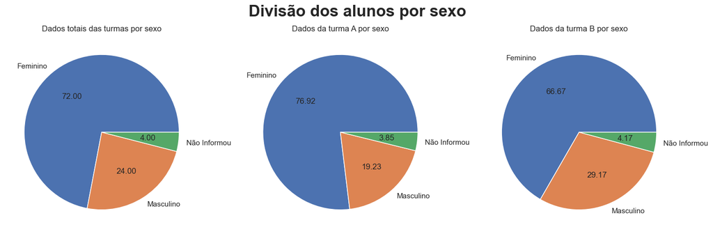

```python
fig, ax = plt.subplots(1, 3, figsize=(15,5))

ax[0].pie(dados, labels=rotulos, autopct='%.2f')
ax[0].set_title('Dados totais das turmas por sexo')

ax[1].pie(dadosA, labels=rotulos, autopct='%.2f')
ax[1].set_title('Dados da turma A por sexo')

ax[2].pie(dadosB, labels=rotulos, autopct='%.2f')
ax[2].set_title('Dados da turma B por sexo')
fig.suptitle('Divisão dos alunos por sexo', fontsize=24, fontweight='bold')
fig.tight_layout()
```

Pode-se notar que a maior parte dos alunos é do sexo feminino.

### 2- Analisando as idades

```
[Text(0.5, 1.0, 'Variação de idades dos alunos')]
```

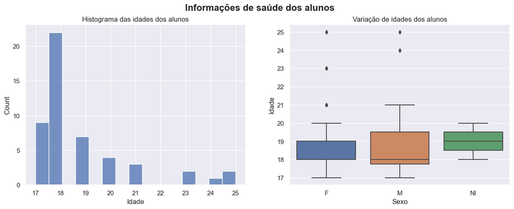

```python
fig, ax = plt.subplots(1, 2, figsize=(15,5))
fig.suptitle('Informações de saúde dos alunos', fontsize=16, fontweight='bold')
#fig.tight_layout()

sns.histplot(df, x='Idade', ax=ax[0]).set(title='Histograma das idades dos alunos')
sns.boxplot(df, x='Sexo', y='Idade', ax=ax[1]).set(title='Variação de idades dos alunos')
```

A idade dos alunos se concentra na faixa etária até 20 anos.

### 3- Analisando as informações de saúde

```python
#função para adicionar informações sobre o ínidice de massa corporal
def bmi_class(bmi):
    bmi_who = [18.5, 25, 30, 35, 40]
    if bmi<bmi_who[0]:
        return 'Baixo Peso'
    elif bmi<bmi_who[1]:
        return 'Peso Normal'
    elif bmi<bmi_who[2]:
        return 'Sobrepeso'
    elif bmi<bmi_who[3]:
        return 'Obesidade Grau I'
    elif bmi<bmi_who[4]:
        return 'Obesidade Grau II'
    elif bmi>=bmi_who[4]:
        return 'Obesidade Grau III'

#calculando o IMC de cada aluno
df['BMI'] = df['Peso']/(df['Alt']**2)

#aplicando a função para classificar o IMC
df['Classe IMC'] = df['BMI'].map(bmi_class)
```

```
[Text(0.5, 1.0, 'Divisão do IMC dos alunos por classe')]
```

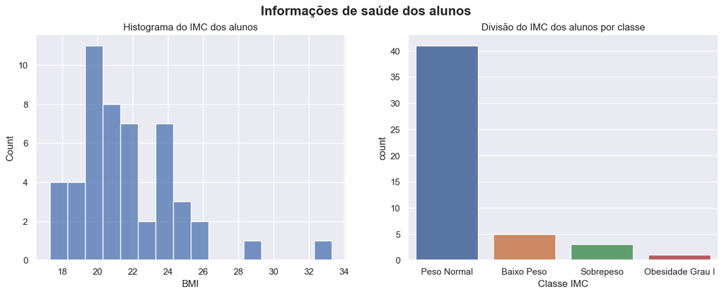

```python
fig, ax = plt.subplots(1, 2, figsize=(15,5))
fig.suptitle('Informações de saúde dos alunos', fontsize=16, fontweight='bold')
#fig.tight_layout()

sns.histplot(df, x='BMI', binwidth=1, ax=ax[0]).set(title='Histograma do IMC dos alunos')
sns.countplot(df, x='Classe IMC', ax=ax[1]).set(title='Divisão do IMC dos alunos por classe')
```

A maioria dos alunos se encontra dentro da faixa normal de peso.

```
[Text(0.5, 1.0, 'Tempo de exercício e a classe de IMC')]
```

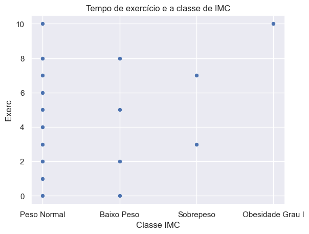

```python
sns.scatterplot(df, x='Classe IMC', y='Exerc').set(title='Tempo de exercício e a classe de IMC')
```

### Relação entre fumar e a tolerância ao cigarro

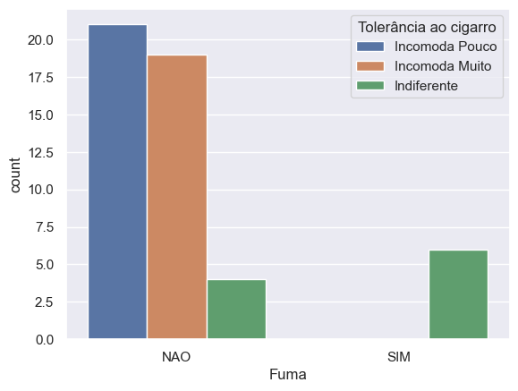

```python
sns.countplot(df, x='Fuma', hue='Toler')
plt.legend(title='Tolerância ao cigarro', labels=['Incomoda Pouco', 'Incomoda Muito', 'Indiferente'])
```

Naturalmente, aqueles que fumam não são incomodadas pelo cigarro.

```
[Text(0.5, 1.0, 'Divisão do IMC dos alunos por classe')]
```

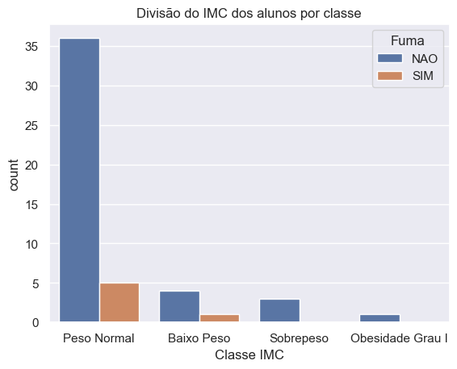

```python
sns.countplot(df, x='Classe IMC', hue='Fuma').set(title='Divisão do IMC dos alunos por classe')
```

Nada pode se concluir sobre a relação entre fumar e o peso.

### 4- Quantidade de alunos com filhos

```
[Text(0.5, 1.0, 'Quantidade de filhos por aluno')]
```

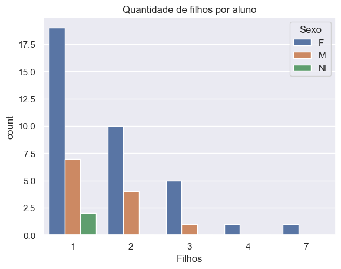

```python
sns.countplot(df, x='Filhos', hue='Sexo').set(title='Quantidade de filhos por aluno')
```

### 5- Análise das variáveis de entretenimento

```
[Text(0.5, 1.0, 'Quantidade de horas e a opinião sobre a qualidade da programação na TV')]
```

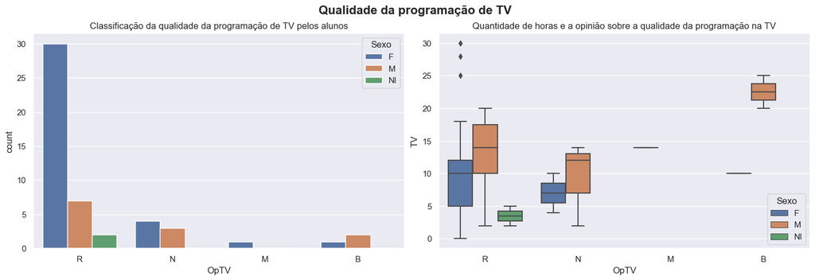

```python
fig, ax = plt.subplots(1, 2, figsize=(15,5))
fig.suptitle('Qualidade da programação de TV', fontsize=16, fontweight='bold')
fig.tight_layout()

sns.countplot(df, x='OpTV', hue='Sexo', ax=ax[0]).set(title='Classificação da qualidade da programação de TV pelos alunos')
sns.boxplot(df, x='OpTV', y='TV', hue='Sexo', ax=ax[1]).set(title='Quantidade de horas e a opinião sobre a qualidade da programação na TV')
```